# U.S Homicide Report from 1980 to 2014

By: Jorelle Kebeto

## Introduction

This dataset was chosen because all over the World and particularly in the United States, homicides happen everyday. It is crucial to know that crime rate tends to increase, so people should be more careful and always be in a position where they are safe. This tutorial will be an analysis of the homicide reports data in the United State from 1980 to 2014. The tutorial has three main parts which are for the first part data collection, preparation and cleaning, the second part is about how to analyse and visualize the data, and the last part is the linear regression model which will allow us to analyse and verify the null hypothesis.

## Libraries

Here we have all the libraries used in analyzing this dataset. Some are used to analyze the dataset while others are added to make the data more appealing. We use the function suppressPackageStartupMessages() to disable messages upon loading a package.

```r
#data manipulation
suppressPackageStartupMessages(library(tidyverse))
suppressPackageStartupMessages(library(stringr))
suppressPackageStartupMessages(library(tidyr))
suppressPackageStartupMessages(library(dplyr))

#aesthetics
suppressPackageStartupMessages(library(broom))
suppressPackageStartupMessages(library(ggplot2))
suppressPackageStartupMessages(library(ggthemes))
suppressPackageStartupMessages(library(leaflet))
suppressPackageStartupMessages(library(htmltools))
suppressPackageStartupMessages(library(rvest))
suppressPackageStartupMessages(library(magrittr))
suppressPackageStartupMessages(library(data.table))
```

## Part 1: Data Preparation

First, we need to download the dataset at https://www.kaggle.com/jyzaguirre/us-homicide-reports. The file downloaded will be in the form of a CSV(Comma-separated value) named database.csv. Once, the data is downloaded, we can easily read it using read_csv.

```r
#Load the csv file and make a dataframe
homicide_data <- read_csv("database.csv")
#view(homicide_data)
#Display the first 6 rows of the table
head(homicide_data)
```

```
## # A tibble: 6 x 24
##   `Record ID` `Agency Code` `Agency Name` `Agency Type` City  State  Year
##   <chr>       <chr>         <chr>         <chr>         <chr> <chr> <dbl>
## 1 000001      AK00101       Anchorage     Municipal Po~ Anch~ Alas~  1980
## 2 000002      AK00101       Anchorage     Municipal Po~ Anch~ Alas~  1980
## 3 000003      AK00101       Anchorage     Municipal Po~ Anch~ Alas~  1980
## 4 000004      AK00101       Anchorage     Municipal Po~ Anch~ Alas~  1980
## 5 000005      AK00101       Anchorage     Municipal Po~ Anch~ Alas~  1980
## 6 000006      AK00101       Anchorage     Municipal Po~ Anch~ Alas~  1980
## # ... with 17 more variables: Month <chr>, Incident <dbl>, `Crime
## #   Type` <chr>, `Crime Solved` <chr>, `Victim Sex` <chr>, `Victim
## #   Age` <dbl>, `Victim Race` <chr>, `Victim Ethnicity` <chr>,
## #   `Perpetrator Sex` <chr>, `Perpetrator Age` <dbl>, `Perpetrator
## #   Race` <chr>, `Perpetrator Ethnicity` <chr>, Relationship <chr>,
## #   Weapon <chr>, `Victim Count` <dbl>, `Perpetrator Count` <dbl>, `Record
## #   Source` <chr>
```

## 1.1 Data Overview

The Homicide report data contains some important information to analyze such as time, locations, crime types, victims, Weapons, and perpetrator.

## 1.2 Data Tyding

Since there are some columns that will not be used in the analysis process, it is preferable to drop these to make the data easy to manipulate. In this particular case, we decide to drop the Agency Code, Agency Name, Agency Type, Record Source and Month.

```r
#Delete columns
homicide_data <- homicide_data[,-c(2,3,4,8,15,19,24)]

#Convert Year type from double to int
homicide_data['Year'] <- type.convert(homicide_data['Year'])
head(homicide_data)
```

```
## # A tibble: 6 x 17
##   `Record ID` City  State  Year Incident `Crime Type` `Crime Solved`
##   <chr>       <chr> <chr> <int>    <dbl> <chr>        <chr>
## 1 000001      Anch~ Alas~  1980        1 Murder or M~ Yes
## 2 000002      Anch~ Alas~  1980        1 Murder or M~ Yes
## 3 000003      Anch~ Alas~  1980        2 Murder or M~ No
## 4 000004      Anch~ Alas~  1980        1 Murder or M~ Yes
## 5 000005      Anch~ Alas~  1980        2 Murder or M~ No
## 6 000006      Anch~ Alas~  1980        1 Murder or M~ Yes
## # ... with 10 more variables: `Victim Sex` <chr>, `Victim Age` <dbl>,
## #   `Victim Race` <chr>, `Perpetrator Sex` <chr>, `Perpetrator Age` <dbl>,
## #   `Perpetrator Race` <chr>, Relationship <chr>, Weapon <chr>, `Victim
## #   Count` <dbl>, `Perpetrator Count` <dbl>
```

For the Homicide Report data analysis, we need to create two tables containing information about victims and perpetrator respectively.

```r
#Create Victim table
victim_data <- homicide_data %>%
  select('Record ID', 'City', 'State', 'Year', 'Crime Type', 'Victim Sex', 'Victim Age', 'Victim Race', 'Victim Count')
#Convert the Victim's Age from type double to int
victim_data['Victim Age'] <- type.convert(victim_data['Victim Age'])


head(as.tibble(victim_data))
```

```
## # A tibble: 6 x 9
##   `Record ID` City  State  Year `Crime Type` `Victim Sex` `Victim Age`
##   <chr>       <chr> <chr> <int> <chr>        <chr>               <int>
## 1 000001      Anch~ Alas~  1980 Murder or M~ Male                   14
## 2 000002      Anch~ Alas~  1980 Murder or M~ Male                   43
## 3 000003      Anch~ Alas~  1980 Murder or M~ Female                 30
## 4 000004      Anch~ Alas~  1980 Murder or M~ Male                   43
## 5 000005      Anch~ Alas~  1980 Murder or M~ Female                 30
## 6 000006      Anch~ Alas~  1980 Murder or M~ Male                   30
## # ... with 2 more variables: `Victim Race` <chr>, `Victim Count` <dbl>
```

Looking at the original data, we notice that there are several cases that were not solved in the column Crime Solved and the perpetrator’s age is zero. This means the identity of the perpetrator is unknown, but there are victims. Since we are creating the table for perpetrators, we will cut off the rows with unsolved cases and where the perpetrator’s age is zero.

```r
#Create perpetrator table
perpetrator_data <- homicide_data %>%
  select('Record ID', 'City', 'State', 'Year', 'Crime Type', 'Crime Solved', 'Perpetrator Sex', 'Perpetrator Age', 'Perpetrator Race', 'Weapon', 'Perpetrator Count')

#Remove any cases that were unsolved
perpetrator_data <- perpetrator_data[perpetrator_data$`Crime Solved` == 'Yes',]

#Remove cases where perpetrator's age is 0
perpetrator_data <- perpetrator_data[perpetrator_data$'Perpetrator Age' != 0,]

#Change the type of Perpetrator Age column from double to integer
   perpetrator_data['Perpetrator Age'] <- type.convert(perpetrator_data['Perpetrator Age'])

head(as.tibble(perpetrator_data))
```

```
## # A tibble: 6 x 11
##   `Record ID` City  State  Year `Crime Type` `Crime Solved`
##   <chr>       <chr> <chr> <int> <chr>        <chr>
## 1 000001      Anch~ Alas~  1980 Murder or M~ Yes
## 2 000002      Anch~ Alas~  1980 Murder or M~ Yes
## 3 000004      Anch~ Alas~  1980 Murder or M~ Yes
## 4 000006      Anch~ Alas~  1980 Murder or M~ Yes
## 5 000007      Anch~ Alas~  1980 Murder or M~ Yes
## 6 000008      Anch~ Alas~  1980 Murder or M~ Yes
## # ... with 5 more variables: `Perpetrator Sex` <chr>, `Perpetrator
## #   Age` <int>, `Perpetrator Race` <chr>, Weapon <chr>, `Perpetrator
## #   Count` <dbl>
```

## Part 2: Exploratory Data Analysis

The Homicide report data is ready to be analyzed. In this part, we will visualize the data that we cleaned up with some plots and maps and explain the trend of homicides in the United States from 1980 to 2014.

## 2.1 Homicide per Year

We would like to analyze the number of homicides that happened throughout between 1980 and 2014 inclusive. First, we will write a query to compute the number of homicides that are taking place every year.

## 2.1.1 Extract the Number of Hommicide per Year

The question to ask in this case is what is the best way to count the number of homicides of a specific year? To answer this question, we will use the function count() and select() to find the result. Documentation about count and select functions can be found here: https://www.rdocumentation.org/packages/plyr/versions/1.8.4/topics/count https://www.rdocumentation.org/packages/dplyr/versions/0.7.8/topics/select

```r
#Compute number of homicides per year
num_hom_year <- homicide_data %>%
  count(Year) %>%
  select(Year, CountOfHomicides = n) %>%
  arrange(Year)
head(num_hom_year)
```

```
## # A tibble: 6 x 2
##    Year CountOfHomicides
##   <int>            <int>
## 1  1980            23092
## 2  1981            21208
## 3  1982            20544
## 4  1983            19653
## 5  1984            18093
## 6  1985            18386
```

## 2.1.2 Visualization of the Number of Homicide per Year

After Extraction of the number of homicide per year, the next step is to plot the data from the previous table.

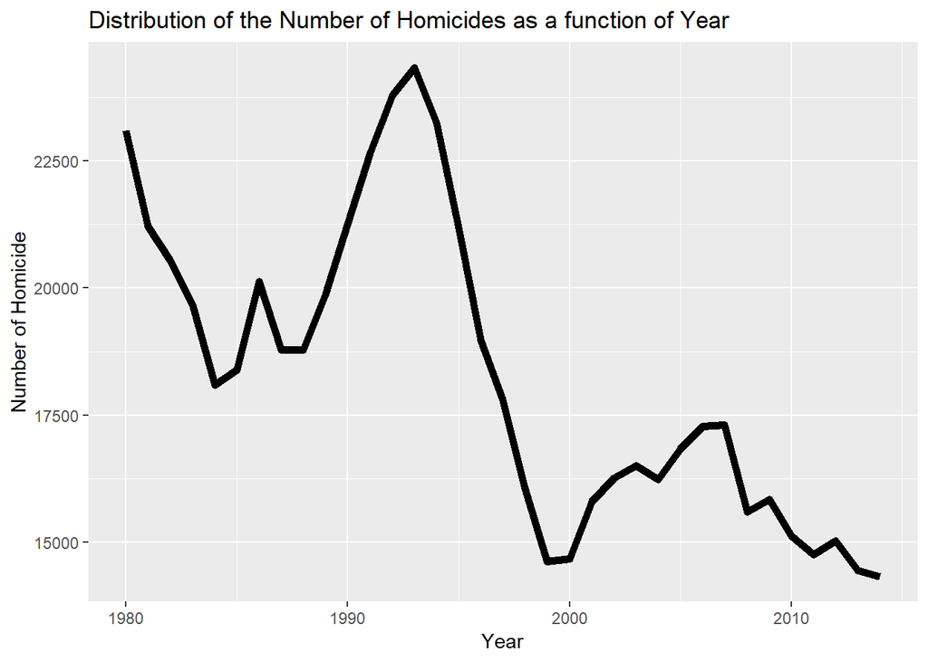

```r
num_hom_year %>% ggplot(mapping=aes(x=Year, y=CountOfHomicides)) +
  geom_line(size = 2) +
  labs(x="Year", y="Number of Homicide", title="Distribution of the Number of Homicides as a function of Year")
```

The number of homicides is decreasing by year for the most parts. The number of homicides reached its maximum between 1990 and 1995. After these years, the number becomes smaller up to the most recent year which is 2014 in this dataset.

## 2.1.3 Mean and Standard Deviation of the Number of Homicide

```r
#Mean of the number of homicides per year
 mean(num_hom_year$CountOfHomicides)
```

```
## [1] 18241.54
```

```r
#Standard deviation of the number of homicides per year
sd(num_hom_year$CountOfHomicides)
```

```
## [1] 2986.447
```

So, the average of homicides is: 18241.54 homicides per year and, the standard deviation is 2986.447

We can conclude that in average, the number of homicides per year is pretty high and the difference number of homicides between year is large as well.

## 2.2 Homicide per State

After finding the number of homicides per year, we will analyze the number of homicides per state in the United States.

## 2.2.1 Extract the Number of Homicide per State

Here we follow the same idea as how to compute the number of homicides per states.

```r
#Compute number of homicides per year
num_hom_state <- homicide_data %>%
  count(State) %>%
  select(State, CountOfHomicides = n) %>%
  arrange(State)
head(num_hom_state)
```

```
## # A tibble: 6 x 2
##   State      CountOfHomicides
##   <chr>                 <int>
## 1 Alabama               11376
## 2 Alaska                 1617
## 3 Arizona               12871
## 4 Arkansas               6947
## 5 California            99783
## 6 Colorado               6593
```

## 2.2.2 Graph of the Number of Homice per State

Here we will first find the top 10 states where the number of homicide is very high, then we will create a histogram to visualize the distribution of homicide for the top 10.

```r
#Compute top 10 states with the highest number of homicide
top_10_hom_state <- homicide_data %>%
  count(State) %>%
  mutate(`CountOfHomicides` = n, Rank = rank(desc(n))) %>%
  select(-n) %>%
  arrange(Rank) %>%
  top_n(n = 10,wt = desc(Rank))
top_10_hom_state
```

```
## # A tibble: 10 x 3
##    State          CountOfHomicides  Rank
##    <chr>                     <int> <dbl>
##  1 California                99783     1
##  2 Texas                     62095     2
##  3 New York                  49268     3
##  4 Florida                   37164     4
##  5 Michigan                  28448     5
##  6 Illinois                  25871     6
##  7 Pennsylvania              24236     7
##  8 Georgia                   21088     8
##  9 North Carolina            20390     9
## 10 Louisiana                 19629    10
```

Let’s display the result using a histogram.

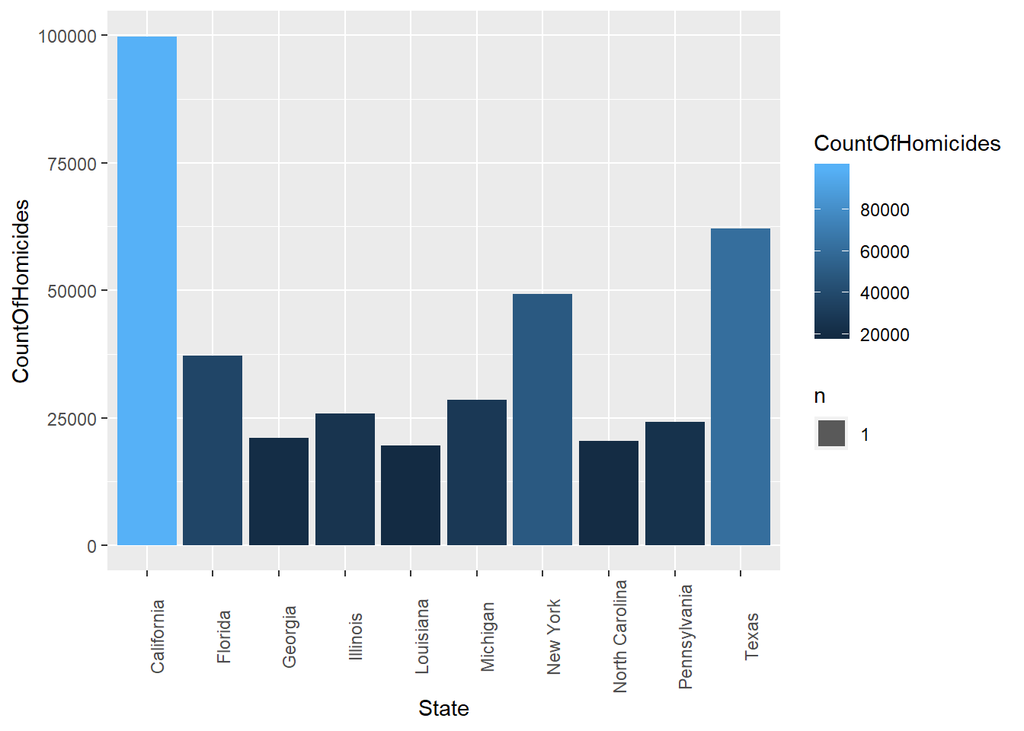

```r
top_10_hom_state %>%
  ggplot(mapping=aes(x=State, y=CountOfHomicides, fill=CountOfHomicides)) +
  geom_bar(stat="sum") +
  theme(axis.text.x = element_text(angle=90, vjust=1.2))
```

When we look at the graph, we see that the state with the largest number of homicides from 1980 to 2014 is California.

Now let’s create a map for our dataset. Since the original dataset does not contain information about the longitude and lattitude of each state, we downloaded a new dataset here https://www.kaggle.com/washimahmed/usa-latlong-for-state-abbreviations containing those information.

## 2.2.3 Map of the Number of Homicides in the U.S

```r
#Read state lat and long file
state_lat_lng <- read_csv("statelatlong.csv")
#Renaming the column
state_lat_lng <- set_colnames(state_lat_lng,c("Abbr", "Lat", "Long", "State"))

#Swap position of column so that the first column is State
state_lat_lng <- state_lat_lng[,c(4, 1,2,3)]
head(state_lat_lng)
```

```
## # A tibble: 6 x 4
##   State      Abbr    Lat   Long
##   <chr>      <chr> <dbl>  <dbl>
## 1 Alabama    AL     32.6  -86.7
## 2 Alaska     AK     61.3 -159.
## 3 Arizona    AZ     34.2 -112.
## 4 Arkansas   AR     34.8  -92.1
## 5 California CA     37.3 -119.
## 6 Colorado   CO     39.0 -106.
```

```r
#Another way to Swap position of column with state as the first column
col_idx <- grep("State", names(homicide_data))
homicide_dat <- homicide_data[, c(col_idx, (1:ncol(homicide_data))[-col_idx])]

#merging the tables
num_hom_state_merg <- merge(num_hom_state, state_lat_lng, by="State", all=TRUE)
head(num_hom_state_merg)
```

```
##        State CountOfHomicides Abbr      Lat       Long
## 1    Alabama            11376   AL 32.60101  -86.68074
## 2     Alaska             1617   AK 61.30250 -158.77502
## 3    Arizona            12871   AZ 34.16822 -111.93091
## 4   Arkansas             6947   AR 34.75193  -92.13138
## 5 California            99783   CA 37.27187 -119.27042
## 6   Colorado             6593   CO 38.99793 -105.55057
```

```r
data_merg <- merge(homicide_data, num_hom_state_merg, by="State", all=TRUE)
head(data_merg)
```

```
##     State Record ID       City Year Incident             Crime Type
## 1 Alabama    000468    Madison 1980        3 Murder or Manslaughter
## 2 Alabama    000225     Mobile 1980        1 Murder or Manslaughter
## 3 Alabama    000291 Montgomery 1980        4 Murder or Manslaughter
## 4 Alabama    266371  Jefferson 1993        1 Murder or Manslaughter
## 5 Alabama    000294 Montgomery 1980        2 Murder or Manslaughter
## 6 Alabama    000222     Mobile 1980        1 Murder or Manslaughter
##   Crime Solved Victim Sex Victim Age Victim Race Perpetrator Sex
## 1          Yes       Male         21       White            Male
## 2          Yes       Male         18       White            Male
## 3          Yes       Male         18       White            Male
## 4          Yes     Female         77       White            Male
## 5          Yes     Female         27       Black          Female
## 6          Yes       Male         32       Black            Male
##   Perpetrator Age Perpetrator Race Relationship  Weapon Victim Count
## 1              24            Black     Stranger Handgun            0
## 2              17            White Acquaintance   Knife            0
## 3              54            Black     Stranger Handgun            0
## 4              26            Black     Stranger Handgun            0
## 5              24            Black Acquaintance Handgun            0
## 6              31            Black Acquaintance Handgun            0
##   Perpetrator Count CountOfHomicides Abbr      Lat      Long
## 1                 0            11376   AL 32.60101 -86.68074
## 2                 0            11376   AL 32.60101 -86.68074
## 3                 0            11376   AL 32.60101 -86.68074
## 4                 0            11376   AL 32.60101 -86.68074
## 5                 0            11376   AL 32.60101 -86.68074
## 6                 0            11376   AL 32.60101 -86.68074
```

Now let’s get a sample of 2000 entities from our dataset and use a map to display specific information about a random person in a particular state. The map gives the information about the number of homicides in that state, the type of weapon the person used, whether or not the crime was solved, the perpetrator race, and age.

```r
df <- data_merg %>%
  sample_n(2000)

map_hom_state <- leaflet(df) %>%
  addTiles() %>%
  addAwesomeMarkers(~Long, ~Lat,
                    popup = paste("Number of Homicides:", df$CountOfHomicides, "<br>",
                                  "Weapon:", df$Weapon, "<br>",
                                  "Crime Solved:", df$`Crime Solved`, "<br>",
                                  "Perpetrator Race:", df$`Perpetrator Race`, "<br>",
                                  "Perpetrator Age:", df$`Perpetrator Age`, "<br>"
                                  ),
                    label = ~~htmlEscape(df$State),
                    labelOptions = labelOptions(noHide = F, direction = "left", style = list(
        "color" = "black",
        "font-family" = "serif",
        "font-style" = "bold",
        "box-shadow" = "3px 3px rgba(0,0,0,0.25)",
        "font-size" = "20px",
        "border-color" = "rgba(0,0,0,0.5)"
      ))) %>%

  setView(lat=48, lng=-102, zoom=4)

map_hom_state
```

[interactive chart not shown]

## 2.3.1 Extract the Number of Homicides per Age

We will use the same strategy used in 2.1.1 using the perpetrator table instead.

```r
#Compute number of homicides per age
num_hom_age <- perpetrator_data %>%
  count(`Perpetrator Age`) %>%
  select(`Perpetrator Age`, CountOfHomicides = n)
  #arrange(Perp)
head(num_hom_age)
```

```
## # A tibble: 6 x 2
##   `Perpetrator Age` CountOfHomicides
##               <int>            <int>
## 1                 1               16
## 2                 2                6
## 3                 3               24
## 4                 4               29
## 5                 5               31
## 6                 6               50
```

## 2.3.2 Graph of the Number of Homicides per Age

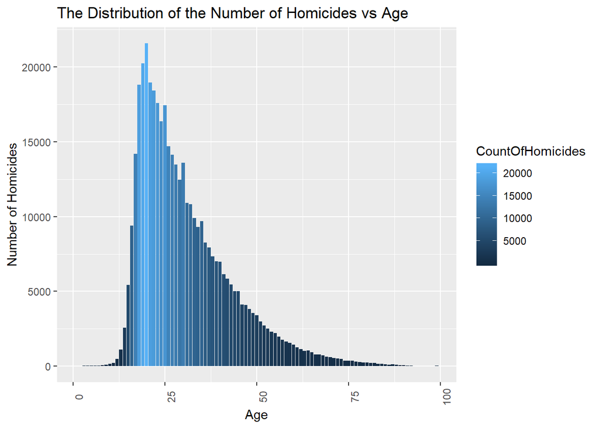

```r
#Compute top 10 states with the highest number of homicide
num_hom_age %>%
  ggplot(mapping=aes(x=`Perpetrator Age`, y=CountOfHomicides, fill=CountOfHomicides)) +
  geom_bar(stat="identity") +
  labs(x="Age", y="Number of Homicides", title="The Distribution of the Number of Homicides vs Age")+

  theme(axis.text.x = element_text(angle=90, vjust=1.2))
```

## Part 3: Linear Regression and Hypothesis Test

This part will focus on linear regression. To do a linear regression, we need data that is collected already. We are going to take a linear regression of the number of homicides across the year and compare it to another regression which is a function of State.

## 3.1 Linear Regression Model

Here, we will create a linear regression model for The Number of Homicide as a function of Year.

```r
#Linear regression model for number of homicides vs years
lmfit <- lm(formula = CountOfHomicides ~ Year, data=data_merg)
tidy(lmfit)
```

```
## # A tibble: 2 x 5
##   term        estimate std.error statistic p.value
##   <chr>          <dbl>     <dbl>     <dbl>   <dbl>
## 1 (Intercept)  369852.   7985.        46.3       0
## 2 Year           -167.      4.00     -41.7       0
```

## 3.2 Linear Regression Model with Interaction

The second linear regression model is for the number of homicides with a term for interaction between state and year. Here we will use the table that we obtained previously.

```r
#Linear regression model with interaction
lmfit2 <- lm(formula = CountOfHomicides ~ Year*State, data=data_merg)
inter_data <- tidy(lmfit2)
head(inter_data)
```

```
## # A tibble: 6 x 5
##   term            estimate std.error statistic  p.value
##   <chr>              <dbl>     <dbl>     <dbl>    <dbl>
## 1 (Intercept)      1.14e+4  3.74e- 7   3.04e10 0.
## 2 Year             1.58e-9  1.87e-10   8.44e 0 3.30e-17
## 3 StateAlaska     -9.76e+3  9.29e- 7  -1.05e10 0.
## 4 StateArizona     1.50e+3  4.97e- 7   3.01e 9 0.
## 5 StateArkansas   -4.43e+3  5.72e- 7  -7.74e 9 0.
## 6 StateCalifornia  8.84e+4  3.91e- 7   2.26e11 0.
```

From the table, we notice the p-value is significantly close to 0.

## 3.3 Graph of the Linear Regression on Homicide per Year

Now let’s graph the regression.

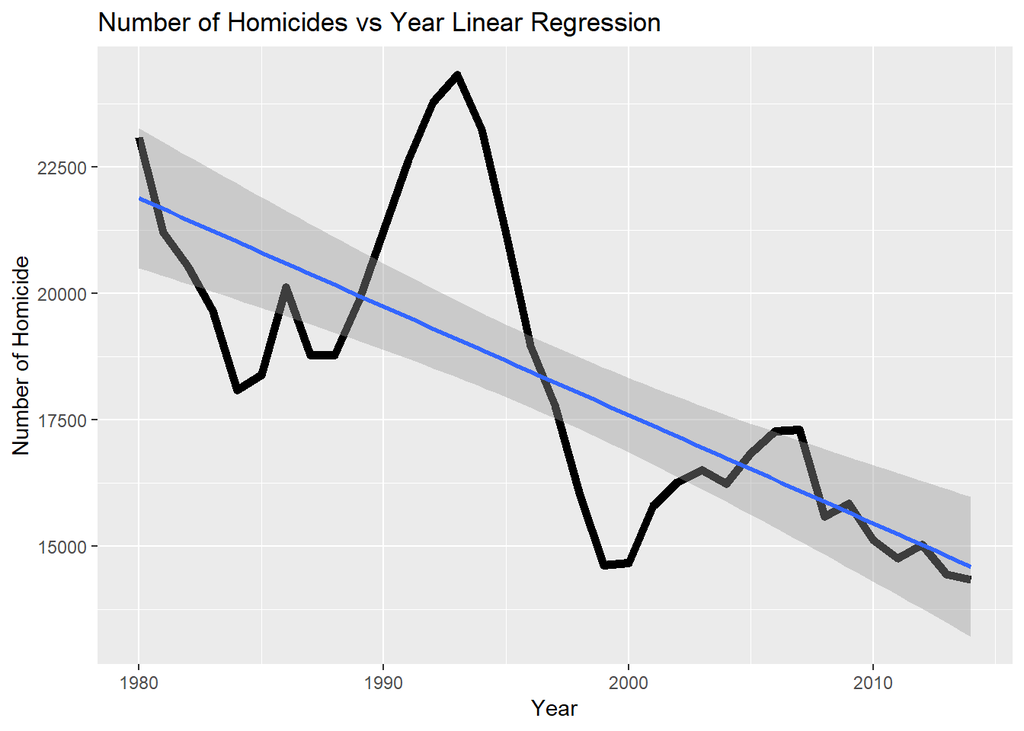

```r
num_hom_year %>% ggplot(mapping=aes(x=Year, y=CountOfHomicides)) +
  geom_line(size = 2) +
  geom_smooth(method=lm) +
  labs(x="Year", y="Number of Homicide", title="Number of Homicides vs Year Linear Regression")
```

## 3.4 Hypothesis Testing

To verify our hypothesis, we will use the ANOVA function to perform an F-test.

## a) Linear regression model without interaction

```r
m1 <- anova(lmfit)
m1
```

```
## Analysis of Variance Table
##
## Response: CountOfHomicides
##               Df     Sum Sq    Mean Sq F value    Pr(>F)
## Year           1 1.7500e+12 1.7500e+12  1737.4 < 2.2e-16 ***
## Residuals 638452 6.4311e+14 1.0073e+09
## ---
## Signif. codes:  0 '***' 0.001 '**' 0.01 '*' 0.05 '.' 0.1 ' ' 1
```

## b) Linear regression model with interaction

```r
anova(lmfit, lmfit2)
```

```
## Analysis of Variance Table
##
## Model 1: CountOfHomicides ~ Year
## Model 2: CountOfHomicides ~ Year * State
##   Res.Df        RSS  Df  Sum of Sq          F    Pr(>F)
## 1 638452 6.4311e+14
## 2 638352 0.0000e+00 100 6.4311e+14 2.0715e+26 < 2.2e-16 ***
## ---
## Signif. codes:  0 '***' 0.001 '**' 0.01 '*' 0.05 '.' 0.1 ' ' 1
```

## Conclusion

The Homicide report in the United States is important because it is good to be aware of how many lives are taken away by homicides and how the homicides are distributed across the year and different states. This tutorial is a guide of how to analyze medium datasets and can help the audience to be more informed about the trends of homicides in the U.S.

After our analysis, we can conclude that the umber of homicides differ per year and per state. An important aspect of this analysis is that we could see that the number of homocides was decreasing as the years were imcreasing. The state with the highest number of homicides is California from 1980 to 2014.

## References

Homicide report dataset:https://www.kaggle.com/jyzaguirre/us-homicide-reports

U.S longitude and latitude data for each state: https://www.kaggle.com/washimahmed/usa-latlong-for-state-abbreviations

R documentation: https://www.rdocumentation.org/packages/methods/versions/3.5.3/topics/Documentation

The map widget: https://rstudio.github.io/leaflet/map_widget.html

Linear Regression Model: http://www.hcbravo.org/IntroDataSci/bookdown-notes/linear-regression.html